# Streaming Success: Unveiling Insights from Netflix Data Analysis

JH Pretorius

2023-06-17

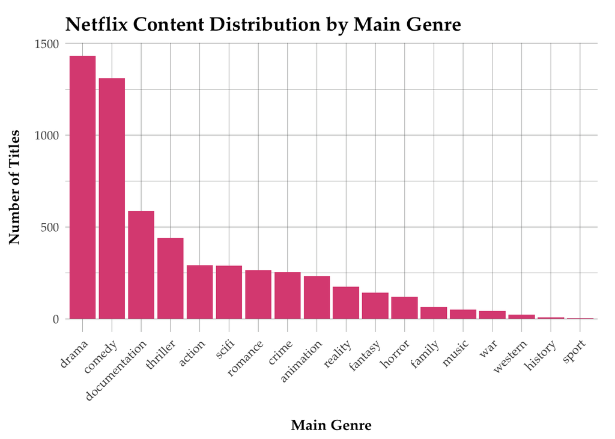

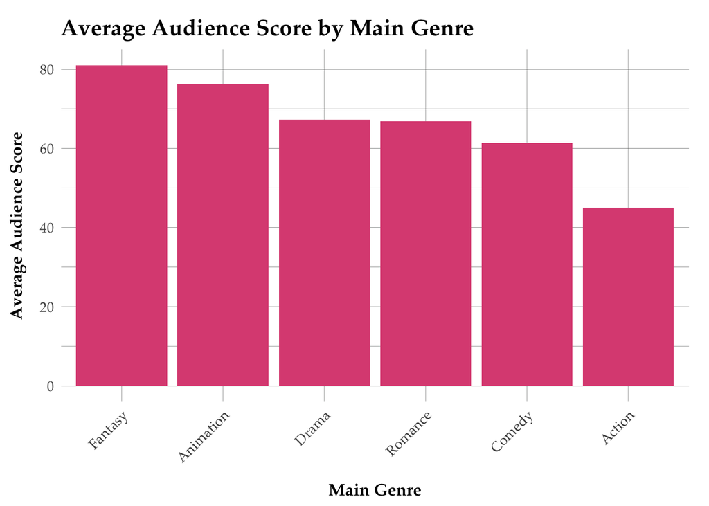

| Main Genre | Average Worldwide Gross | Average Profitability |
| --- | --- | --- |
| Animation | 356.77681 | 3.216561 |
| Fantasy | 285.43100 | 1.783944 |
| Romance | 133.54210 | 4.371398 |
| Comedy | 130.50258 | 3.935434 |
| Drama | 99.01137 | 8.407218 |
| Action | 93.40000 | 1.245333 |

Based on the data, it is evident that drama and comedy films dominate the Netflix library, while animation and fantasy titles are relatively low in number. However, it is important to note that fantasy, animation, and drama genres receive high audience scores on IMDb, indicating strong viewer satisfaction.

Considering these findings, Netflix should consider expanding its content offerings in the fantasy and animation genres to cater to the audience’s preferences and capitalize on their popularity. By diversifying its library with more fantasy and animation titles, Netflix can attract a larger audience and potentially increase viewer engagement. Additionally, continuing to invest in drama and comedy films, which are already popular genres, can help maintain the existing viewer base.

Overall, a strategic approach for Netflix would involve balancing its content portfolio by increasing the availability of fantasy and animation titles while continuing to deliver compelling drama and comedy films to meet the preferences of a wide range of viewers.